# Assignment 5

```r
cat("
<style>
h2 {
  font-size: 24px;
  color:#045a8d;
  text-align:center;
}

h3 {
  font-size: 14px;
  color:#2b8cbe;
  text-align:center;
}

h4 {
  font-size: 14px;
  color:#2b8cbe;
}
</style>
")
```

## Part I: Bivariate Regression

### 1.

#### Specify null and alternative hypotheses for the relationship between government health expenditures and happiness. Explain in a few sentences how and why you expect health expenditures to affect happiness levels.

- Null hypothesis: there is no relationship between government health expenditures and happiness
- Alternative hypothesis: there is a positive relationship between government health expenditures and happiness

Government spends money on health = healthy citizens = happy citizens. Unhealthy citizens are unhappy.

### 2.

Calculate the following:

#### A)

Regression coefficient estimates for gov_health expenditures and the intercept.

```r
Countries=read.csv("http://www.sfu.ca/~sweldon/Countries.csv")

# only get the two columns relevant
subset_data = Countries[,c("happy", "gov_health")]

# remove missing data
subset_data = subset_data[complete.cases(subset_data),]

values_diff <- sum((subset_data$gov_health - mean(subset_data$gov_health))*(subset_data$happy - mean(subset_data$happy)))
x_diff_squared <- sum((subset_data$gov_health - mean(subset_data$gov_health))^2)
n = nrow(subset_data)

(slope = values_diff/x_diff_squared)
```

```
## [1] 0.01314422
```

```r
(intercept = mean(subset_data$happy) - slope*mean(subset_data$gov_health))
```

```
## [1] 0.7190307
```

#### B)

The Root Mean Standard Error or Residual Standard Error.

```r
# y_pred = a + bX
y_pred = intercept + slope*subset_data$gov_health
RMSE = sqrt(mean((subset_data$happy-y_pred)^2))
```

[output not shown]

#### C)

The R-squared and Adjusted R-squared values

```r
y = subset_data$happy
mss= sum((y_pred - mean(y))^2)
tss = sum((y - mean(y))^2)
rsquared = mss/tss
rsquared
```

```
## [1] 0.04841057
```

[figure not shown]

```r
rsquared_adjust = 1-((1-rsquared)*(n-1)/(n-1-1))
rsquared_adjust
```

```
## [1] 0.03783736
```

4. The standard error for the gov_health expenditures coefficient.

```r
residuals = sum((y_pred-y)^2)
sigma_squared = residuals/(n-2)
(se = sqrt(sigma_squared/x_diff_squared))
```

```
## [1] 0.006142828
```

5. The t-value and p-value for the gov_health expenditures coefficient.

```r
(tval = (slope-0)/se)
```

```
## [1] 2.139767
```

```r
(pval = pt(q = tval, df = n-1, lower.tail = F))
```

```
## [1] 0.0175247
```

## Part II: Multiple Regression – Height, Weight, and Gender

Download the Height, Weight and Gender Data Set with:

```r
HW = read.csv("http://www.sfu.ca/~sweldon/Height_and_Weight.csv")
```

### 1.

#### Do a regression of weight on height. Do you get a statistically significant coefficient for the height variable? Why or why not?

```r
summary(lm(Weight ~ Height, HW))
```

```
##
## Call:
## lm(formula = Weight ~ Height, data = HW)
##
## Residuals:
##     Min      1Q  Median      3Q     Max
## -29.328 -15.139   0.777  12.949  44.076
##
## Coefficients:
##             Estimate Std. Error t value Pr(>|t|)
## (Intercept) -93.5262    53.3293  -1.754  0.08969 .
## Height        3.3508     0.8221   4.076  0.00031 ***
## ---
## Signif. codes:  0 '***' 0.001 '**' 0.01 '*' 0.05 '.' 0.1 ' ' 1
##
## Residual standard error: 18.49 on 30 degrees of freedom
## Multiple R-squared:  0.3564, Adjusted R-squared:  0.335
## F-statistic: 16.61 on 1 and 30 DF,  p-value: 0.0003097
```

Yes, significant. Because taller people weigh more

### 2.

#### Do a regression of weight on gender. Do you get a statistically significant coefficient for the gender variable? Why or why not?

```r
summary(lm(Weight ~ Gender, HW))
```

```
##
## Call:
## lm(formula = Weight ~ Gender, data = HW)
##
## Residuals:
##     Min      1Q  Median      3Q     Max
## -22.808 -15.558  -4.308   7.942  54.192
##
## Coefficients:
##             Estimate Std. Error t value Pr(>|t|)
## (Intercept)  117.808      3.847  30.621  < 2e-16 ***
## Genderm       30.026      8.885   3.379  0.00203 **
## ---
## Signif. codes:  0 '***' 0.001 '**' 0.01 '*' 0.05 '.' 0.1 ' ' 1
##
## Residual standard error: 19.62 on 30 degrees of freedom
## Multiple R-squared:  0.2757, Adjusted R-squared:  0.2516
## F-statistic: 11.42 on 1 and 30 DF,  p-value: 0.00203
```

Yes, because men weigh more than women

### 3.

#### Create a scatterplot showing height on the x axis and women’s weights and men’s weights separately on the y axis. What do you think this scatterplot shows about the relationship between weight, height and gender?

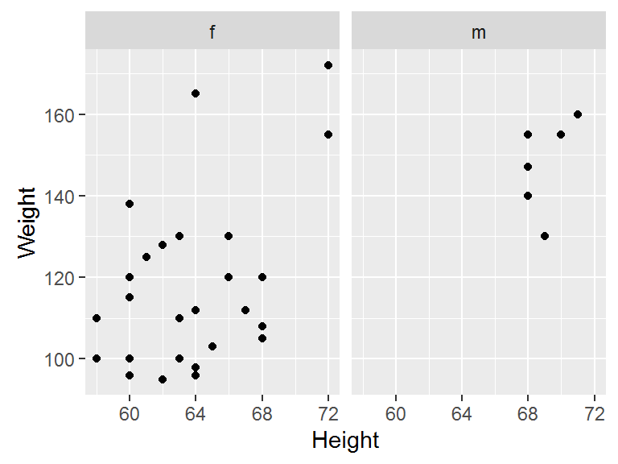

```r
ggplot(HW, aes(Height, Weight)) +
  geom_point() +
  facet_wrap(~Gender)
```

### 4.

#### For the scatterplot you created for question 3, insert a regression line regressing weight on height for women only; Calculate the R2 value. For that same scatterplot, insert a second regression line regressing weight on height for men only; Calculate the r2 value. What do you think these two regression lines show about the relationship between weight, height and gender?

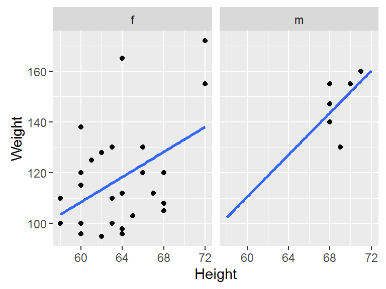

```r
ggplot(HW, aes(Height, Weight)) +
  geom_point() +
  geom_smooth(method = "lm", fullrange=T, se = FALSE) +
  facet_wrap(~Gender)
```

```r
# men R2 value
men_data <- subset(HW, Gender == "m")
summary(lm(Weight ~ Height, men_data))$r.squared
```

```
## [1] 0.215786
```

```r
# women R2 value
women_data <- subset(HW, Gender == "f")
summary(lm(Weight ~ Height, women_data))$r.squared
```

```
## [1] 0.2021229
```

These regression lines show that there is a weak relationship between height and weight for each of the genders.

### 5.

#### Run a multiple regression of weight on both height and the gender dummy. What do you think this new regression shows about the relationship between weight, height and gender? Based on this regression would you conclude that the relationship between weight and height was different for men and women to a statistically significant degree? Why or why not? (HINT: is the t-statistic on the gender coefficient statistically significant?)

```r
summary(lm(Weight ~ Height + Gender, HW))
```

```
##
## Call:
## lm(formula = Weight ~ Height + Gender, data = HW)
##
## Residuals:
##     Min      1Q  Median      3Q     Max
## -23.365 -14.374  -3.393  10.146  46.616
##
## Coefficients:
##             Estimate Std. Error t value Pr(>|t|)
## (Intercept) -41.3258    59.0224  -0.700   0.4894
## Height        2.4955     0.9239   2.701   0.0114 *
## Genderm      16.9725     9.4130   1.803   0.0818 .
## ---
## Signif. codes:  0 '***' 0.001 '**' 0.01 '*' 0.05 '.' 0.1 ' ' 1
##
## Residual standard error: 17.83 on 29 degrees of freedom
## Multiple R-squared:  0.4213, Adjusted R-squared:  0.3814
## F-statistic: 10.56 on 2 and 29 DF,  p-value: 0.0003594
```

No, I would not conclude that the relationship between weight and height was different for men and women to a statistically significant degree. This is because the p-value of gender is 0.08, which is above the 0.05 cutoff.

### 6.

#### Why do you think you found a statistically significant relationship between gender and weight for the analysis you ran for question 2, but not question 5? Be as specific as possible, in particular about what happens when you analyze the joint effects of gender and height on weight.

I previously found a statistically significant relationship because men tend to weigh more than women simply because men are also taller than women. However, in the multivariate regression, men and women who weigh similar are compared to each other rather than all men and women and so the difference in heights between men and women are no longer confounding.

### 7.

#### Based on your own commonsense observations about the world, do you really believe that the relationship between weight and height is the same for men and women, i.e., that for a given height, we would expect men and women to have roughly the same weight? If not, why not?

No, because men stil typically weigh more than a woman of equal height

### 8.

#### In the regression you ran for question 5 you did not get a statistically significant value for gender. How might the fact that you only had data from a handful of men affect whether or not you got a statistically significant result in that regression? (Give a clear and precise answer to this question.)

Because the sample size is small, the standard error of the estimate is high. Given a higher sample size, the standard error will decrease and thus may lead to signifigance.

### 9.

#### What do you think would happen if you took the same data you have on height, weight and gender and “cloned” it, i.e., ran a regression on a data set that was, for example, twice the size by “copying and pasting” the original data set a second time? What do you think should happen to the t-statistic for height? Why? What do you think should happen to the t-statistic for gender? Why? Hint: Think quite carefully about your answer to this question, before you move on to the next question.

If the data was cloned, then the standard error would decrease on the coefficient estimate and as a result the t statistic would increase. Furthermore, becaues the degrees of freedom increases the critical value for the t-statistic would decrease. Therefore, the results may end up to be statistically significant

### 10.

#### OK, now try it. Create a new data set that includes the original data set and a cloned copy of that data set. To do this use the “rbind” function as follows, creating a new data set called HW2:

Now run a multivariate regression of weight on height and gender for this new 64 case data set. Note: If you have attached the HW data set, be sure to detach it and attach the new HW2 data set.

What actually does happen to these two t-statistics from question 8 above? Can you explain what’s going on in your own words?

```r
HW2 = rbind(HW,HW)
summary(lm(Weight ~ Height + Gender, HW2))
```

```
##
## Call:
## lm(formula = Weight ~ Height + Gender, data = HW2)
##
## Residuals:
##     Min      1Q  Median      3Q     Max
## -23.365 -14.374  -3.393  10.146  46.616
##
## Coefficients:
##             Estimate Std. Error t value Pr(>|t|)
## (Intercept) -41.3258    40.6959  -1.015 0.313889
## Height        2.4955     0.6371   3.917 0.000229 ***
## Genderm      16.9725     6.4903   2.615 0.011226 *
## ---
## Signif. codes:  0 '***' 0.001 '**' 0.01 '*' 0.05 '.' 0.1 ' ' 1
##
## Residual standard error: 17.39 on 61 degrees of freedom
## Multiple R-squared:  0.4213, Adjusted R-squared:  0.4023
## F-statistic:  22.2 on 2 and 61 DF,  p-value: 5.688e-08
```

### 11.

#### Before moving on, this is a good time to be sure that we understand the relationship between t-statistics/scores and p-values. What is the relationship? If you do not understand how t-statistics are related to p-values, take some time to look at the regression equations you have run—though also note that it is the same that it has always been for the various test statistics.

Higher T-statistic = higher lower p-value

### 12.

#### Now, finally, one more thought experiment. Imagine that you create a new data set that is seven times the original data set. What do you think should happen to the t-statistic for height? Why? What do you think should happen to the t-statistic for gender? Why? Hint: Think carefully about your answer to these questions.

The formula to calculate the T-Statistic is as follows:

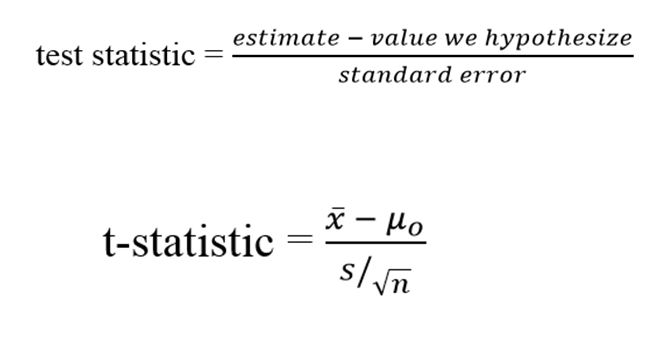

If the N was increased by 7 times, then the T-statistic (for both height and gender) would increase by roughly `sqrt(7)` times. This is because `mean(x)` and the alternative hypothesis are constant, so the numerator for the t-statistic is constant. Also, the standard error is roughly constant since residuals is increased by 7 times but `n-2` is roughly increasd by 7 times. However, an multiplying `n` by 7 means that the `s/sqrt(n)` term decreases (by roughly `sqrt(7) times)`, which means the total value is roughly `sqrt(7)` times larger.